```python
# Initialize Otter
import otter
grader = otter.Notebook("hw3.ipynb")
```

# CPSC 330 - Applied Machine Learning

## Homework 3: Preprocessing

### Associated lectures: [Lectures 4, 5, 6](https://github.com/UBC-CS/cpsc330-2023s/tree/main/lectures)

**Due date: See the [Calendar](https://htmlpreview.github.io/?https://github.com/UBC-CS/cpsc330-2023s/blob/master/docs/calendar.html).**

## Imports

```python
from hashlib import sha1
import matplotlib.pyplot as plt
import numpy as np
import pandas as pd
from sklearn.compose import ColumnTransformer, make_column_transformer
from sklearn.dummy import DummyClassifier
from sklearn.impute import SimpleImputer
from sklearn.model_selection import cross_val_score, cross_validate, train_test_split
from sklearn.neighbors import KNeighborsClassifier
from sklearn.pipeline import Pipeline, make_pipeline
from sklearn.preprocessing import OneHotEncoder, StandardScaler, OrdinalEncoder
from sklearn.svm import SVC
from sklearn.tree import DecisionTreeClassifier
```

## Instructions

rubric={points:6}

Follow the [homework submission instructions](https://github.com/UBC-CS/cpsc330-2023s/blob/main/docs/homework_instructions.md).

**You may work with a partner on this homework and submit your assignment as a group.** Below are some instructions on working as a group.

- The maximum group size is 2.
- Use group work as an opportunity to collaborate and learn new things from each other.
- Be respectful to each other and make sure you understand all the concepts in the assignment well.
- It's your responsibility to make sure that the assignment is submitted by one of the group members before the deadline.
- You can find the instructions on how to do group submission on Gradescope [here](https://help.gradescope.com/article/m5qz2xsnjy-student-add-group-members).

*Note: The assignments will get gradually more open-ended as we progress through the course. In many cases, there won't be a single correct solution. Sometimes you will have to make your own choices and your own decisions (for example, on what parameter values to use when they are not explicitly provided in the instructions). Use your own judgment in such cases and justify your choices, if necessary.*

## Introduction

A crucial step when using machine learning algorithms on real-world datasets is preprocessing. This homework will give you some practice of data preprocessing and building a supervised machine learning pipeline on a real-world dataset.

## Exercise 1: Introducing the dataset

In this lab, you will be working on [the adult census dataset](https://www.kaggle.com/uciml/adult-census-income#). Download the CSV and save it as `adult.csv` under the data folder in this homework folder.

This is a classification dataset and the classification task is to predict whether income exceeds 50K per year or not based on the census data. You can find more information on the dataset and features [here](http://archive.ics.uci.edu/ml/datasets/Adult).

The starter code below loads the data CSV (assuming that it is saved as `adult.csv` under the data folder).

*Note that many popular datasets have sex as a feature where the possible values are male and female. This representation reflects how the data were collected and is not meant to imply that, for example, gender is binary.*

```python
census_df = pd.read_csv("data/adult.csv")
census_df.shape
```

```
(32561, 15)
```

### 1.1 Data splitting

rubric={autograde:2}

In order to avoid violation of the golden rule, the first step before we do anything is splitting the data.

**Your tasks:**

1. Split the data into `train_df` (40%) and `test_df` (60%) with `random_state = 123`. Keep the target column (`income`) in the splits so that we can use it in the exploratory data analysis.

*Usually having more data for training is a good idea. But here I'm using 40%/60% split because running cross-validation with this dataset can take a while on a modest laptop. A smaller training data means it won't take too long to train the model on your laptop. A side advantage of this would be that with a bigger test split, we'll have a more reliable estimate of the model performance!*

Solution_1.1

*Points:* 2

```python
train_df, test_df = train_test_split(census_df, test_size=0.6, random_state=123)
```

```python
grader.check("q1.1")
```

```
q1.1
```

passed! 🌟

## Exercise 2: Exploratory data analysis (EDA)

Let's examine our `train_df`.

```python
train_df.sort_index()
```

|  | age | workclass | fnlwgt | education | education.num | marital.status | occupation | relationship | race | sex | capital.gain | capital.loss | hours.per.week | native.country | income |
| --- | --- | --- | --- | --- | --- | --- | --- | --- | --- | --- | --- | --- | --- | --- | --- |
| 0 | 90 | ? | 77053 | HS-grad | 9 | Widowed | ? | Not-in-family | White | Female | 0 | 4356 | 40 | United-States | <=50K |
| 1 | 82 | Private | 132870 | HS-grad | 9 | Widowed | Exec-managerial | Not-in-family | White | Female | 0 | 4356 | 18 | United-States | <=50K |
| 4 | 41 | Private | 264663 | Some-college | 10 | Separated | Prof-specialty | Own-child | White | Female | 0 | 3900 | 40 | United-States | <=50K |
| 5 | 34 | Private | 216864 | HS-grad | 9 | Divorced | Other-service | Unmarried | White | Female | 0 | 3770 | 45 | United-States | <=50K |
| 6 | 38 | Private | 150601 | 10th | 6 | Separated | Adm-clerical | Unmarried | White | Male | 0 | 3770 | 40 | United-States | <=50K |
| ... | ... | ... | ... | ... | ... | ... | ... | ... | ... | ... | ... | ... | ... | ... | ... |
| 32554 | 32 | Private | 116138 | Masters | 14 | Never-married | Tech-support | Not-in-family | Asian-Pac-Islander | Male | 0 | 0 | 11 | Taiwan | <=50K |
| 32556 | 22 | Private | 310152 | Some-college | 10 | Never-married | Protective-serv | Not-in-family | White | Male | 0 | 0 | 40 | United-States | <=50K |
| 32557 | 27 | Private | 257302 | Assoc-acdm | 12 | Married-civ-spouse | Tech-support | Wife | White | Female | 0 | 0 | 38 | United-States | <=50K |
| 32559 | 58 | Private | 151910 | HS-grad | 9 | Widowed | Adm-clerical | Unmarried | White | Female | 0 | 0 | 40 | United-States | <=50K |
| 32560 | 22 | Private | 201490 | HS-grad | 9 | Never-married | Adm-clerical | Own-child | White | Male | 0 | 0 | 20 | United-States | <=50K |

13024 rows × 15 columns

We see some missing values represented with a "?". Probably these were the questions not answered by some people during the census. Usually `.describe()` or `.info()` methods would give you information on missing values. But here, they won't pick "?" as missing values because they are encoded as strings instead of an actual NaN in Python. So let's replace them with `np.nan` before we carry out EDA. If you do not do it, you'll encounter an error later on when you try to pass this data to a classifier.

```python
train_df = train_df.replace("?", np.nan)
test_df = test_df.replace("?", np.nan)
train_df.shape
```

```
(13024, 15)
```

```python
train_df.sort_index()
```

|  | age | workclass | fnlwgt | education | education.num | marital.status | occupation | relationship | race | sex | capital.gain | capital.loss | hours.per.week | native.country | income |
| --- | --- | --- | --- | --- | --- | --- | --- | --- | --- | --- | --- | --- | --- | --- | --- |
| 0 | 90 | NaN | 77053 | HS-grad | 9 | Widowed | NaN | Not-in-family | White | Female | 0 | 4356 | 40 | United-States | <=50K |
| 1 | 82 | Private | 132870 | HS-grad | 9 | Widowed | Exec-managerial | Not-in-family | White | Female | 0 | 4356 | 18 | United-States | <=50K |
| 4 | 41 | Private | 264663 | Some-college | 10 | Separated | Prof-specialty | Own-child | White | Female | 0 | 3900 | 40 | United-States | <=50K |
| 5 | 34 | Private | 216864 | HS-grad | 9 | Divorced | Other-service | Unmarried | White | Female | 0 | 3770 | 45 | United-States | <=50K |
| 6 | 38 | Private | 150601 | 10th | 6 | Separated | Adm-clerical | Unmarried | White | Male | 0 | 3770 | 40 | United-States | <=50K |
| ... | ... | ... | ... | ... | ... | ... | ... | ... | ... | ... | ... | ... | ... | ... | ... |
| 32554 | 32 | Private | 116138 | Masters | 14 | Never-married | Tech-support | Not-in-family | Asian-Pac-Islander | Male | 0 | 0 | 11 | Taiwan | <=50K |
| 32556 | 22 | Private | 310152 | Some-college | 10 | Never-married | Protective-serv | Not-in-family | White | Male | 0 | 0 | 40 | United-States | <=50K |
| 32557 | 27 | Private | 257302 | Assoc-acdm | 12 | Married-civ-spouse | Tech-support | Wife | White | Female | 0 | 0 | 38 | United-States | <=50K |
| 32559 | 58 | Private | 151910 | HS-grad | 9 | Widowed | Adm-clerical | Unmarried | White | Female | 0 | 0 | 40 | United-States | <=50K |
| 32560 | 22 | Private | 201490 | HS-grad | 9 | Never-married | Adm-clerical | Own-child | White | Male | 0 | 0 | 20 | United-States | <=50K |

13024 rows × 15 columns

The "?" symbols are now replaced with NaN values.

### 2.1 `describe()` method

rubric={autograde:5}

**Your tasks:**

1. Examine the output of `train_df.describe()` with `include='all'` argument and store it in a variable called `census_summary`.
2. What is the highest hours per week someone reported? Store it in a variable called `max_hours_per_week`.
3. What is the most frequently occurring occupation in this dataset? Store it in a variable called `most_freq_occupation`.
4. Store the column names of the columns with missing values as a list in a variable called `missing_vals_cols`.
5. Store the column names of all numeric-looking columns as a list in a variable called `numeric_cols`.

Solution_2.1

*Points:* 5

```python
census_summary = train_df.describe(include='all')
census_summary
```

|  | age | workclass | fnlwgt | education | education.num | marital.status | occupation | relationship | race | sex | capital.gain | capital.loss | hours.per.week | native.country | income |
| --- | --- | --- | --- | --- | --- | --- | --- | --- | --- | --- | --- | --- | --- | --- | --- |
| count | 13024.000000 | 12284 | 1.302400e+04 | 13024 | 13024.000000 | 13024 | 12281 | 13024 | 13024 | 13024 | 13024.000000 | 13024.000000 | 13024.000000 | 12783 | 13024 |
| unique | NaN | 8 | NaN | 16 | NaN | 7 | 14 | 6 | 5 | 2 | NaN | NaN | NaN | 40 | 2 |
| top | NaN | Private | NaN | HS-grad | NaN | Married-civ-spouse | Prof-specialty | Husband | White | Male | NaN | NaN | NaN | United-States | <=50K |
| freq | NaN | 9123 | NaN | 4153 | NaN | 5936 | 1649 | 5195 | 11158 | 8700 | NaN | NaN | NaN | 11717 | 9875 |
| mean | 38.546913 | NaN | 1.884759e+05 | NaN | 10.057432 | NaN | NaN | NaN | NaN | NaN | 1079.831695 | 86.543074 | 40.395654 | NaN | NaN |
| std | 13.610225 | NaN | 1.040895e+05 | NaN | 2.553084 | NaN | NaN | NaN | NaN | NaN | 7322.034546 | 403.025863 | 12.285347 | NaN | NaN |
| min | 17.000000 | NaN | 1.376900e+04 | NaN | 1.000000 | NaN | NaN | NaN | NaN | NaN | 0.000000 | 0.000000 | 1.000000 | NaN | NaN |
| 25% | 28.000000 | NaN | 1.170962e+05 | NaN | 9.000000 | NaN | NaN | NaN | NaN | NaN | 0.000000 | 0.000000 | 40.000000 | NaN | NaN |
| 50% | 37.000000 | NaN | 1.778990e+05 | NaN | 10.000000 | NaN | NaN | NaN | NaN | NaN | 0.000000 | 0.000000 | 40.000000 | NaN | NaN |
| 75% | 48.000000 | NaN | 2.365655e+05 | NaN | 12.000000 | NaN | NaN | NaN | NaN | NaN | 0.000000 | 0.000000 | 45.000000 | NaN | NaN |
| max | 90.000000 | NaN | 1.184622e+06 | NaN | 16.000000 | NaN | NaN | NaN | NaN | NaN | 99999.000000 | 4356.000000 | 99.000000 | NaN | NaN |

```python
max_hours_per_week = float(train_df['hours.per.week'].max())
max_hours_per_week
```

```
99.0
```

```python
most_freq_occupation = train_df['occupation'].mode()[0]
```

```python
missing_vals_cols = train_df.columns[train_df.isnull().any()].tolist()
numeric_cols = train_df.select_dtypes(include=[np.number]).columns.tolist()
numeric_cols
```

```
['age',
 'fnlwgt',
 'education.num',
 'capital.gain',
 'capital.loss',
 'hours.per.week']
```

```python
# Sorting the lists for the autograder
missing_vals_cols.sort()
numeric_cols.sort()
```

```python
grader.check("q2.1")
```

```
q2.1
```

passed! 💯

### 2.2 Visualizing features

rubric={points:5}

**Your tasks:**

1. Visualize the histograms of numeric features.
2. From the visualizations, which features seem relevant for the given prediction task?

Solution_2.2

*Points:* 5

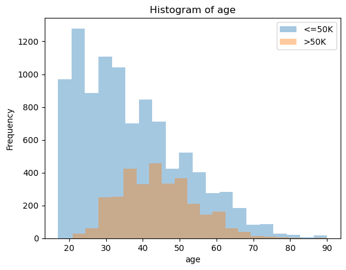

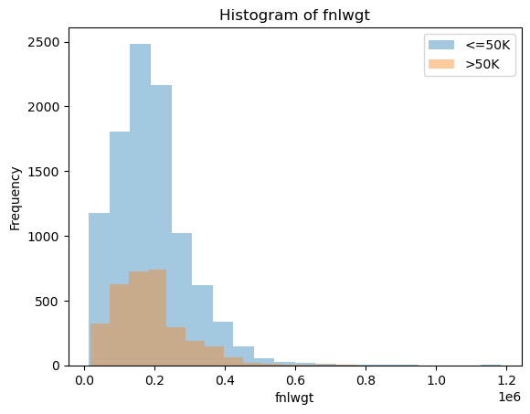

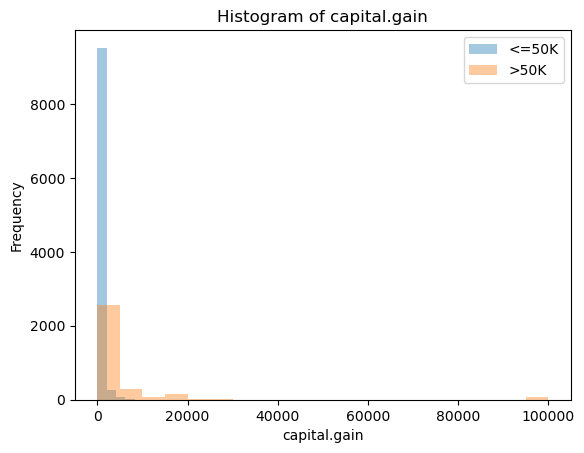

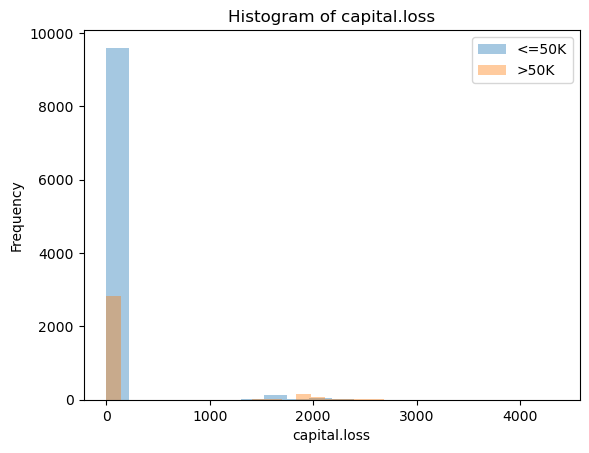

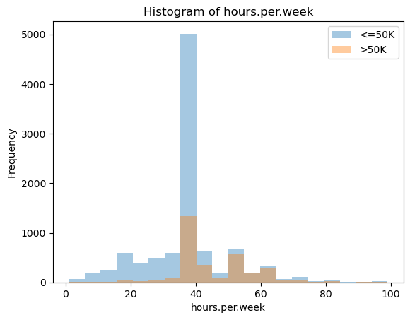

```python
numeric_features = [
    "age",
    "fnlwgt",
    "capital.gain",
    "capital.loss",
    "hours.per.week",
]
train_df_by_income = train_df.groupby("income")
for feat in numeric_features:
    ax = train_df_by_income[feat].plot.hist(bins=20, alpha=0.4, legend=True)
    plt.xlabel(feat)
    plt.title("Histogram of " + feat)
    plt.show()
```

### 2.3 Identify transformations to apply

rubric={points:13}

Before passing this data to a machine learning model, we need to apply some transformations on different features. Below we are providing possible transformations which can be applied on each column in `census_df`.

**Your tasks:**

1. Write your justification or explanation for each row in the explanation column. An example explanation is given for the age column.

> Note: This question is a bit open-ended. If you do not agree with the provided transformation, feel free to argue your case in the explanation. That said, in this assignment, go with the transformations provided below.

Solution_2.3

[output not shown]

*Points:* 13

### 2.4 Identify feature types

rubric={autograde:5}

**Your tasks:**

1. Based on the types of transformations you want to apply on the features, identify different feature types and store them in the variables below as lists.

Solution_2.4

*Points:* 5

```python
numeric_features = ["age", "capital.gain", "capital.loss", "hours.per.week"]
categorical_features = ["workclass", "marital.status", "occupation", "relationship", "native.country"]
ordinal_features = ["education"]
binary_features = ["sex"]
drop_features = ["fnlwgt", "education.num", "race"]
target = "income"
```

```python
# Sorting all the lists above for the autograder
numeric_features.sort()
categorical_features.sort()
ordinal_features.sort()
binary_features.sort()
drop_features.sort()
```

```python
grader.check("q2.4")
```

```
q2.4
```

passed! 🙌

## Exercise 3: Baseline models

### 3.1 Separating feature vectors and targets

rubric={autograde:2}

**Your tasks:**

1. Create `X_train`, `y_train`, `X_test`, `y_test` from `train_df` and `test_df`.

Solution_3.1

*Points:* 2

```python
X_train = train_df.drop(columns=['income'])
y_train = train_df['income']

X_test = test_df.drop(columns=['income'])
y_test = test_df['income']
```

```python
grader.check("q3.1")
```

```
q3.1
```

passed! 🚀

### 3.2 Dummy classifier

rubric={autograde:2}

**Your tasks:**

1. Carry out 5-fold cross-validation using `scikit-learn`'s `cross_validate` function with `return_train_scores=True` and store the results as a dataframe named `dummy_df` where each row corresponds to the results from a cross-validation fold.

Solution_3.2

*Points:* 2

```python
from sklearn.dummy import DummyClassifier
from sklearn.model_selection import cross_validate

dummy = DummyClassifier(strategy='most_frequent')

cv_results = cross_validate(dummy, X_train, y_train, return_train_score=True, cv=5)

dummy_df = pd.DataFrame(cv_results)
```

```python
grader.check("q3.2")
```

```
q3.2
```

passed! 🌟

### 3.3 Discussion

rubric={points:2}

**Your tasks:**

1. Hopefully, you were able to run cross-validation with dummy classifier successfully in the question above. At this point, if you train [`sklearn`'s `SVC`](https://scikit-learn.org/stable/modules/generated/sklearn.svm.SVC.html) model on `X_train` and `y_train` would it work? Why or why not?

Solution_3.3

*Points:* 2

Maybe ANS is NO.Attempting to train sklearn's Support Vector Classifier (SVC) model directly on X_train and y_train would likely fail due to several potential issues inherent in real-world datasets. Firstly, SVC is incapable of handling missing values, which are commonly present in datasets. Thus, preprocessing steps such as imputation would be necessary to fill in these gaps. Secondly, SVC requires numerical input and is unable to process categorical features directly. Consequently, any categorical features in the dataset would need to be converted into a numerical format, for instance, via one-hot encoding. Lastly, SVC is particularly sensitive to the scale of the features. If the dataset contains features of vastly different scales, this could adversely affect the model's performance. To mitigate this, feature scaling, such as standard scaling, can be applied to adjust the range of the features to a similar scale. Therefore, while it's theoretically possible to apply an SVC model to any dataset, the practical application requires thorough preprocessing of the data to ensure it's in an appropriate form for the model to function effectively.

## Exercise 4: Preprocessing

In this dataset, we have different types of features: numeric features, an ordinal feature, categorical features, and a binary feature. We want to apply different transformations on different columns and therefore we need a column transformer. In this exercise, first, we'll define different transformations on different types of features and then will create a `scikit-learn`'s `ColumnTransformer`. For example, the code below creates a `numeric_transformer` for numeric features.

```python
numeric_transformer = StandardScaler()
```

In the exercises below, you'll create transformers for other types of features.

### 4.1 Preprocessing ordinal features

rubric={autograde:5}

**Your tasks:**

1. Create a transformer called `ordinal_transformer` for our ordinal features.

Solution_4.1

*Points:* 5

```python
from sklearn.preprocessing import OrdinalEncoder
ordinal_transformer = OrdinalEncoder(categories=[education_levels], dtype=int)
```

```python
grader.check("q4.1")
```

```
q4.1
```

passed! 💯

### 4.2 Preprocessing binary features

rubric={autograde:2}

**Your tasks:**

1. Create a transformer called `binary_transformer` for our binary features.

> *Note that many popular datasets have sex as a feature where the possible values are male and female. This representation reflects how the data were collected and is not meant to imply that, for example, gender is binary.*

Solution_4.2

*Points:* 2

```python
from sklearn.preprocessing import OneHotEncoder

binary_transformer = OneHotEncoder(drop="if_binary", dtype=int)
```

```python
grader.check("q4.2")
```

```
q4.2
```

passed! 🌟

### 4.3 Preprocessing categorical features

rubric={autograde:4}

In Exercise 2.3, we saw that there are 3 categorical features with missing values. So first we need to impute the missing values and then encode these features with one-hot encoding. For the purpose of this assignment, let's just have imputation as the first step for all categorical features even when they do not have missing values. This should be OK because if a feature doesn't have any missing value, imputation won't be applied.

If we want to apply more than one transformation on a set of features, we need to create a [`scikit-learn` `Pipeline`](https://scikit-learn.org/stable/modules/generated/sklearn.pipeline.Pipeline.html). For example, for categorical features we can create a `scikit-learn` `Pipeline` with first step as imputation and the second step as one-hot encoding.

**Your tasks:**

1. Create a `sklearn` `Pipeline` using [`make_pipeline`](https://scikit-learn.org/stable/modules/generated/sklearn.pipeline.make_pipeline.html) called `categorical_transformer` for our categorical features with two steps: `SimpleImputer` for imputation with `strategy="constant"` and `fill_value="missing"` and `OneHotEncoder` with `handle_unknown="ignore"` and `sparse=False` for one-hot encoding.

Solution_4.3

*Points:* 4

```python
categorical_transformer = make_pipeline(
    SimpleImputer(strategy="constant", fill_value="missing"),
    OneHotEncoder(handle_unknown="ignore", sparse=False),
)
```

```python
grader.check("q4.3")
```

```
q4.3
```

passed! 🙌

### 4.4 Creating a column transformer.

rubric={autograde:7}

**Your tasks:**

1. Create a `sklearn` `ColumnTransformer` named `preprocessor` using [`make_column_transformer`](https://scikit-learn.org/stable/modules/generated/sklearn.compose.make_column_transformer.html) with the transformers defined in the previous exercises. Use the sequence below in the column transformer and add a "drop" step for the `drop_features` in the end.
   - `numeric_transformer`
   - `ordinal_transformer`
   - `binary_transformer`
   - `categorical_transformer`
2. Transform the data by calling `fit_transform` on the training set and save it as a dataframe in a variable called `transformed_df`. How many new columns have been created in the preprocessed data in comparison to the original `X_train`? Store the difference between the number of columns in `transformed_df` and `X_train` in a variable called `n_new_cols`.

Solution_4.4

*Points:* 7

```python
preprocessor = make_column_transformer(
    (numeric_transformer, numeric_features),
    (ordinal_transformer, ordinal_features),
    (binary_transformer, binary_features),
    (categorical_transformer, categorical_features),
    ("drop", drop_features),
)
```

```python
transformed_df = pd.DataFrame(preprocessor.fit_transform(X_train))
n_new_cols = transformed_df.shape[1] - X_train.shape[1]
```

```python
grader.check("q4.4")
```

```
q4.4
```

passed! 🙌

## Exercise 5: Building models

Now that we have preprocessed features, we are ready to build models. Below, I'm providing the function we used in class which returns mean cross-validation score along with standard deviation for a given model. Use it to keep track of your results.

```python
results_dict = {}  # dictionary to store all the results
```

```python
def mean_std_cross_val_scores(model, X_train, y_train, **kwargs):
    """
    Returns mean and std of cross validation

    Parameters
    ----------
    model :
        scikit-learn model
    X_train : numpy array or pandas DataFrame
        X in the training data
    y_train :
        y in the training data

    Returns
    ----------
        pandas Series with mean scores from cross_validation
    """

    scores = cross_validate(model, X_train, y_train, **kwargs)

    mean_scores = pd.DataFrame(scores).mean()
    std_scores = pd.DataFrame(scores).std()
    out_col = []

    for i in range(len(mean_scores)):
        out_col.append((f"%0.3f (+/- %0.3f)" % (mean_scores[i], std_scores[i])))

    return pd.Series(data=out_col, index=mean_scores.index)
```

Below I'm showing an example where I call `mean_std_cross_val_scores` with `DummyClassifier`. The function calls `cross_validate` with the passed arguments and returns a series with mean cross-validation results and std of cross-validation. When you train new models, you can just add the results of these models in `results_dict`, which can be easily converted to a dataframe so that you can have a table with all your results.

```python
# Baseline model

from sklearn.dummy import DummyClassifier

dummy = DummyClassifier(random_state = 123)
pipe = make_pipeline(preprocessor, dummy)
results_dict["dummy"] = mean_std_cross_val_scores(
    pipe, X_train, y_train, cv=5, return_train_score=True
)
results_df = pd.DataFrame(results_dict).T
results_df
```

|  | fit_time | score_time | test_score | train_score |
| --- | --- | --- | --- | --- |
| dummy | 0.025 (+/- 0.001) | 0.012 (+/- 0.001) | 0.758 (+/- 0.000) | 0.758 (+/- 0.000) |

### 5.1 Trying different classifiers

rubric={points:10}

**Your tasks:**

1. For each of the models in the starter code below:
   - Define a pipeline with two steps: `preprocessor` from 4.4 and the model as your classifier.
   - Carry out 5-fold cross-validation with the pipeline and get the mean cross-validation scores with std by calling the `mean_std_cross_val_scores` function above.
   - Store the results in a dataframe called `income_pred_results_df` with the model names in the `models` dictionary below as the index and each row representing results returned by `mean_std_cross_val_scores` function above. In other words, `income_pred_results_df` should look similar to the `results_df` dataframe above with more rows for the models below.

> This might take a while to run. Be patient!

```python
models = {
    "decision tree": DecisionTreeClassifier(random_state=123),
    "kNN": KNeighborsClassifier(),
    "RBF SVM": SVC(random_state=123),
}
```

Solution_5.1

*Points:* 10

```python
income_pred_results_df = pd.DataFrame()


for model_name, model in models.items():

    pipeline = make_pipeline(preprocessor, model)


    results = mean_std_cross_val_scores(pipeline, X_train, y_train, cv=5, return_train_score=True)


    income_pred_results_df = income_pred_results_df.append(results, ignore_index=True)


income_pred_results_df.index = models.keys()
```

```python
income_pred_results_df
```

|  | fit_time | score_time | test_score | train_score |
| --- | --- | --- | --- | --- |
| decision tree | 0.081 (+/- 0.002) | 0.011 (+/- 0.001) | 0.814 (+/- 0.012) | 0.987 (+/- 0.001) |
| kNN | 0.029 (+/- 0.001) | 0.184 (+/- 0.055) | 0.836 (+/- 0.008) | 0.883 (+/- 0.002) |
| RBF SVM | 2.211 (+/- 0.161) | 1.017 (+/- 0.007) | 0.852 (+/- 0.005) | 0.855 (+/- 0.002) |

### 5.2 Discussion

rubric={points:5}

**Your tasks:**

1. Examine the train and validation accuracies and `fit` and `score` times for all the models in the results above. How do the validation accuracies compare to the `DummyClassifier` model? Which model has the best validation accuracy? Which model is the fastest one? Which model is overfitting the most and the least?

Solution_5.2

*Points:* 5

Based on the provided results, let's examine the train and validation accuracies, as well as the fit and score times for all the models:

### 5.3 Hyperparameter optimization

rubric={points:10}

In this exercise, you'll carry out hyperparameter optimization for the hyperparameter `C` of SVC RBF classifier. In practice, you'll carry out hyperparameter optimization for all different hyperparameters of the most promising classifiers. For the purpose of this assignment, we'll only do it for the `SVC` classifier with one hyperparameter, namely `C`.

**Your tasks:**

1. For each `C` value in the `param_grid` below:
   - Create a pipeline object with two steps: preprocessor from 4.4 and `SVC` classifier with the `C` value.
   - Carry out 5-fold cross validation with the pipeline.
   - Store the results in `results_dict` and display results as a pandas DataFrame.
2. Which hyperparameter value seems to be performing the best? Store it in a variable called `best_C`. (Since this question is not autograded, please store the value directly as a number, something like `best_C = 0.001`, if `C = 0.001` is giving you the best CV score.) Is it different than the default value for the hyperparameter used by `scikit-learn`?

> Note: Running this will take a while. Please be patient.

```python
param_grid = {"C": np.logspace(-1, 2, 4)}
param_grid
```

```
{'C': array([  0.1,   1. ,  10. , 100. ])}
```

Solution_5.3

*Points:* 10

```python
for param in param_grid["C"]:
    model_name = "RBF SVC"
    pipe = make_pipeline(preprocessor, SVC(C=param))

    key = f"{model_name} (C={param})"
    results_dict[key] = mean_std_cross_val_scores(
        pipe, X_train, y_train, cv=5, return_train_score=True
    )
```

```python
results_df = pd.DataFrame(results_dict).T
results_df
```

[output not shown]

```python
best_C = 100
```

## Exercise 6: Evaluating on the test set

Now that we have a best performing model, it's time to assess our model on the set aside test set. In this exercise, you'll examine whether the results you obtained using cross-validation on the train set are consistent with the results on the test set.

### 6.1 Scoring on the unseen test set

rubric={autograde:4}

**Your tasks:**

Solution_6.1

*Points:* 4

```python
final_pipeline = make_pipeline(preprocessor, SVC(C=best_C))


final_pipeline.fit(X_train, y_train)


test_score = final_pipeline.score(X_test, y_test)
```

```python
grader.check("q6.1")
```

```
q6.1
```

passed! 🍀

## Exercise 7: Short answer questions

### 7.1 kNNs toy example

rubric={points:3}

Suppose you want to get predictions using the $k$-nearest neighbour algorithm on the toy dataset below.

$$ X = \begin{bmatrix}5 & 2\\4 & -2\\ 2 & 2\\ 10 & 10\\ 9 & -1\\ 9& 9\end{bmatrix}, \quad y = \begin{bmatrix}0\\0\\1\\1\\1\\2\end{bmatrix}.$$

Suppose you are given a new data point $x=\begin{bmatrix} 0\\0\end{bmatrix}$.

1. What would the model predict when $k=1$?
2. What would the model predict when $k=3$?
3. What would the model predict when $k=3$ if we were doing regression rather than classification?

*Points:* 3

### 7.2 Preprocessing

rubric={points:8}

1. What is the problem with calling `fit_transform` on your test data with `StandardScaler`?
2. Why is it important to follow the Golden Rule? If you violate it, will that give you a worse classifier?
3. What are two advantages of using sklearn Pipelines?
4. When is it appropriate to use sklearn `ColumnTransformer`?

*Points:* 8

The problem with calling fit_transform on the test data with StandardScaler is that it can introduce data leakage, as the scaler should only be fitted on the training data to ensure unbiased evaluation on unseen data. It is important to follow the Golden Rule because it simulates the real-world scenario where the model encounters new, unseen data, and violating it can result in over-optimistic performance estimates and poor generalization to new data. Two advantages of using scikit-learn Pipelines are streamlined workflow organization, as it encapsulates preprocessing and model training into a single object, and automated parameter tuning using GridSearchCV and RandomizedSearchCV for improved performance. Scikit-learn's ColumnTransformer is appropriate when you have different types of features and want to apply specific preprocessing steps to each type, ensuring separate transformations on training and test data and maintaining data integrity during preprocessing.

## Submission instructions

**PLEASE READ:** When you are ready to submit your assignment do the following:

1. Run all cells in your notebook to make sure there are no errors by doing `Kernel -> Restart Kernel and Clear All Outputs` and then `Run -> Run All Cells`.
2. Notebooks with cell execution numbers out of order or not starting from “1” will have marks deducted. Notebooks without the output displayed may not be graded at all (because we need to see the output in order to grade your work).
3. Upload the assignment using Gradescope's drag and drop tool. Check out this [Gradescope Student Guide](https://lthub.ubc.ca/guides/gradescope-student-guide/) if you need help with Gradescope submission.

Congratulations on finishing the homework! This was a tricky one but I hope you are feeling good after working on it. You are now ready to build a simple supervised machine learning pipeline on real-world datasets! Well done :clap:!

[figure not shown]